# Scientific Institutions: Location Data & ZIP-Code Distance Pipeline

## Part 2: Federal Research Labs

Manually curated list of ~50 major federal research facilities. Coordinates verified against agency websites and OpenStreetMap. This list intentionally covers the largest, most prominent labs — it is not exhaustive of every federal facility, but captures the institutions most relevant to structural proximity to organized science.

```r
federal_labs <- tribble(
  ~name,                                          ~agency,  ~lat,     ~lon,
  # ── Department of Energy national labs ─────────────────────────────────
  "Argonne National Laboratory",                  "DOE",   41.7059, -87.9837,
  "Brookhaven National Laboratory",               "DOE",   40.8674, -72.8776,
  "Fermi National Accelerator Laboratory",        "DOE",   41.8319, -88.2617,
  "Idaho National Laboratory",                    "DOE",   43.5246,-112.9541,
  "Lawrence Berkeley National Laboratory",        "DOE",   37.8755,-122.2477,
  "Lawrence Livermore National Laboratory",       "DOE",   37.6868,-121.7051,
  "Los Alamos National Laboratory",               "DOE",   35.8800,-106.2951,
  "National Renewable Energy Laboratory",         "DOE",   39.7405,-105.1686,
  "Oak Ridge National Laboratory",                "DOE",   35.9310, -84.3100,
  "Pacific Northwest National Laboratory",        "DOE",   46.3440,-119.2785,
  "Sandia National Laboratories (NM)",            "DOE",   34.9653,-106.3969,
  "Sandia National Laboratories (CA)",            "DOE",   37.9717,-121.7046,
  "SLAC National Accelerator Laboratory",         "DOE",   37.4160,-122.2034,
  "Ames National Laboratory",                     "DOE",   42.0267, -93.7317,
  "Jefferson Lab",                                "DOE",   37.0977, -76.4791,
  "Savannah River National Laboratory",           "DOE",   33.3487, -81.7229,
  "National Energy Technology Laboratory",        "DOE",   39.9279, -79.9701,
  # ── National Institutes of Health ──────────────────────────────────────
  "NIH Main Campus",                              "NIH",   39.0007, -77.1055,
  "NIH Rocky Mountain Labs",                      "NIH",   46.8574,-113.9867,
  "NIH Research Triangle Park",                   "NIH",   35.8973, -78.8622,
  # ── National Institute of Standards and Technology ──────────────────────
  "NIST Gaithersburg",                            "NIST",  39.1330, -77.2177,
  "NIST Boulder",                                 "NIST",  40.0050,-105.2625,
  # ── NOAA research labs ──────────────────────────────────────────────────
  "NOAA Earth System Research Lab (Boulder)",     "NOAA",  39.9950,-105.2639,
  "NOAA Geophysical Fluid Dynamics Lab",          "NOAA",  40.3502, -74.6573,
  "NOAA Atlantic Oceanographic Lab (Miami)",      "NOAA",  25.7306, -80.1625,
  "NOAA Pacific Marine Environmental Lab",        "NOAA",  47.6456,-122.3130,
  "NOAA National Severe Storms Lab",              "NOAA",  35.1817, -97.4432,
  "NOAA Great Lakes Environmental Research Lab",  "NOAA",  42.2986, -83.7082,
  # ── NASA field centers ───────────────────────────────────────────────────
  "NASA Ames Research Center",                    "NASA",  37.4094,-122.0640,
  "NASA Armstrong Flight Research Center",        "NASA",  34.9594,-117.8822,
  "NASA Glenn Research Center",                   "NASA",  41.4273, -81.8633,
  "NASA Goddard Space Flight Center",             "NASA",  38.9915, -76.8404,
  "NASA Jet Propulsion Laboratory",               "NASA",  34.2014,-118.1720,
  "NASA Johnson Space Center",                    "NASA",  29.5593, -95.0938,
  "NASA Kennedy Space Center",                    "NASA",  28.5729, -80.6490,
  "NASA Langley Research Center",                 "NASA",  37.0837, -76.3694,
  "NASA Marshall Space Flight Center",            "NASA",  34.7293, -86.6650,
  "NASA Stennis Space Center",                    "NASA",  30.3629, -89.6003,
  # ── USGS science centers ─────────────────────────────────────────────────
  "USGS National Center (Reston)",                "USGS",  38.9476, -77.3673,
  "USGS Western Region (Menlo Park)",             "USGS",  37.4574,-122.1730,
  "USGS Central Region (Denver)",                 "USGS",  39.7543,-104.8797,
  "USGS Woods Hole Coastal Science Center",       "USGS",  41.5250, -70.6710,
  "USGS Columbia Environmental Research Center",  "USGS",  38.9387, -92.3341,
  "USGS Patuxent Wildlife Research Center",       "USGS",  38.9980, -76.8155,
  # ── CDC / EPA ────────────────────────────────────────────────────────────
  "CDC / ATSDR (Atlanta)",                        "CDC",   33.7993, -84.3277,
  "EPA Office of Research & Development (RTP)",   "EPA",   35.8905, -78.8751,
  "EPA National Risk Management Lab (Cincinnati)","EPA",   39.1290, -84.5122
) |>
  mutate(institution_type = "federal_lab",
         carnegie_class   = NA_character_,
         city             = NA_character_,
         state_abbr       = NA_character_)

cat("Federal labs:", nrow(federal_labs), "\n")
```

```
Federal labs: 47
```

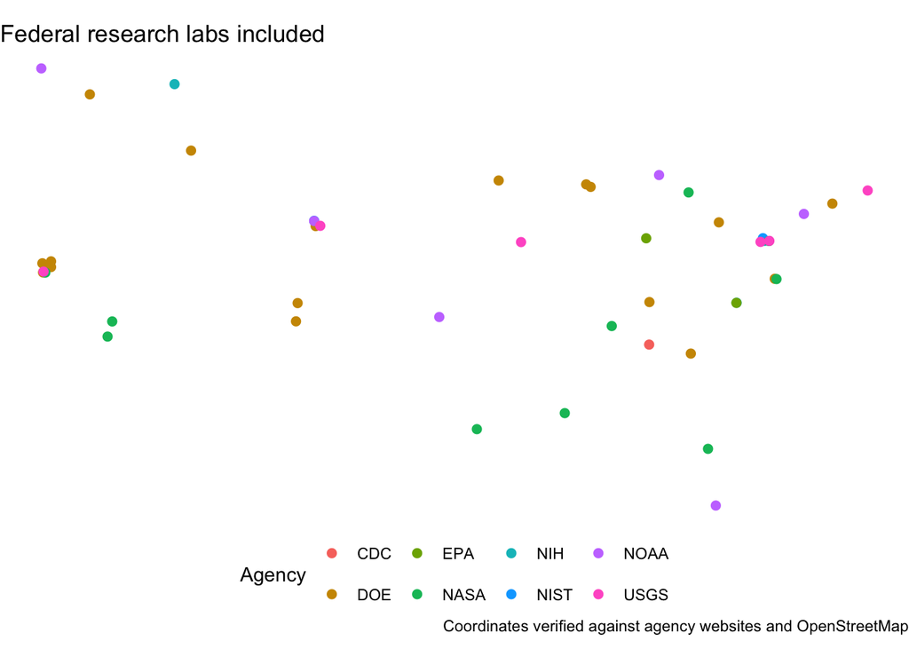

```r
labs_sf <- st_as_sf(federal_labs, coords = c("lon", "lat"), crs = 4326)

ggplot() +
  geom_sf(data = labs_sf, aes(color = agency), size = 2) +
  labs(title = "Federal research labs included",
       color = "Agency",
       caption = "Coordinates verified against agency websites and OpenStreetMap") +
  theme_void() +
  theme(legend.position = "bottom")
```

## Part 3: Combined Institution Dataset

```r
institutions <- bind_rows(
  universities |> select(name, city, state_abbr, lat, lon,
                          carnegie_class, institution_type),
  federal_labs |> select(name, city, state_abbr, lat, lon,
                          carnegie_class, institution_type)
)

institutions |>
  count(institution_type, carnegie_class) |>
  knitr::kable(caption = "Institution counts by type")
```

Institution counts by type

| institution_type | carnegie_class | n |
| --- | --- | --- |
| federal_lab | NA | 47 |
| university | R1 | 131 |
| university | R2 | 131 |

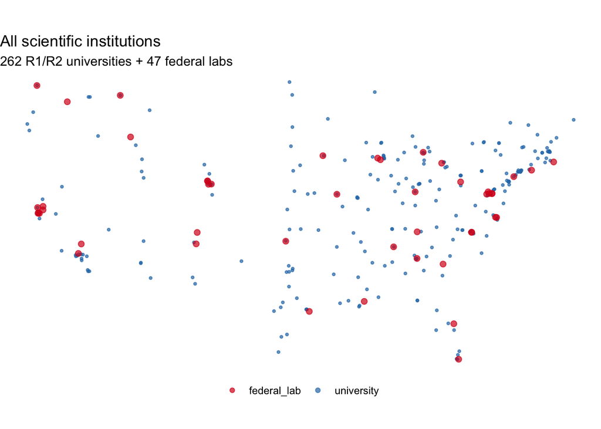

```r
inst_sf <- st_as_sf(institutions, coords = c("lon", "lat"), crs = 4326)

ggplot() +
  geom_sf(data = inst_sf,
          aes(color = institution_type, size = institution_type),
          alpha = 0.7) +
  scale_color_manual(values = c(university = "#2c7bb6", federal_lab = "#d7191c"),
                     name = NULL) +
  scale_size_manual(values  = c(university = 0.8, federal_lab = 2),
                    guide   = "none") +
  labs(title    = "All scientific institutions",
       subtitle = paste0(sum(institutions$institution_type == "university"),
                         " R1/R2 universities + ",
                         sum(institutions$institution_type == "federal_lab"),
                         " federal labs")) +
  theme_void() +
  theme(legend.position = "bottom")
```

```r
saveRDS(institutions, here("data", "institutions", "institutions.rds"))
cat("Saved institutions.rds:", nrow(institutions), "rows\n")
```

```
Saved institutions.rds: 309 rows
```

## Part 4: ZIP Code Distance Pipeline

For each US ZIP code, we compute the geodesic distance (km) to the nearest institution using the Haversine formula. ZIP-code centroids come from `zipcodeR::zip_code_db`, which covers all ~40,000 US ZIP codes with no API calls required.

We restrict to the continental US (latitude 24°–50°, longitude −125° to −66°) to match the participant sample and the institution coverage above.

```r
zips <- zip_code_db |>
  filter(
    !is.na(lat), !is.na(lng),
    lat  > 24 & lat  < 50,
    lng > -125 & lng < -66
  ) |>
  select(zip_code = zipcode, zip_lat = lat, zip_lon = lng)

cat("ZIP codes in continental US:", nrow(zips), "\n")
```

```
ZIP codes in continental US: 32657
```

```r
# Convert to sf for fast nearest-neighbor search
zips_sf  <- st_as_sf(zips, coords = c("zip_lon", "zip_lat"), crs = 4326)
inst_sf2 <- st_as_sf(institutions, coords = c("lon", "lat"),  crs = 4326)

# Find index of nearest institution for each ZIP code
nearest_idx <- st_nearest_feature(zips_sf, inst_sf2)

# Retrieve institution metadata for each matched row
nearest_inst <- institutions[nearest_idx, ] |>
  select(nearest_institution = name, institution_type)

# Compute Haversine distance (km) between each ZIP centroid and its nearest institution
inst_coords <- cbind(institutions$lon[nearest_idx],
                     institutions$lat[nearest_idx])
zip_coords  <- cbind(zips$zip_lon, zips$zip_lat)

dist_km <- distHaversine(zip_coords, inst_coords) / 1000

zipcode_distances <- bind_cols(zips, nearest_inst) |>
  mutate(dist_inst_km = dist_km)

head(zipcode_distances)
```

```
  zip_code zip_lat zip_lon                 nearest_institution institution_type
1    35004   33.62  -86.50 University of Alabama at Birmingham       university
2    35005   33.59  -86.99 University of Alabama at Birmingham       university
3    35006   33.40  -87.20           The University of Alabama       university
4    35007   33.22  -86.79 University of Alabama at Birmingham       university
5    35010   32.90  -85.90                   Auburn University       university
6    35013   33.90  -86.40 University of Alabama at Birmingham       university
  dist_inst_km
1     30.54386
2     20.02362
3     38.40107
4     31.81551
5     51.04835
6     57.39679
```

### Validation

```r
summary(zipcode_distances$dist_inst_km)
```

```
    Min.  1st Qu.   Median     Mean  3rd Qu.     Max.
  0.0291  28.7875  62.2344  77.5828 103.8492 581.0799
```

```r
# NYC (10001) → should be near 0; rural Montana (59931) → should be large
zipcode_distances |>
  filter(zip_code %in% c("10001", "59931", "90210", "60601", "73301")) |>
  select(zip_code, nearest_institution, institution_type, dist_inst_km) |>
  mutate(dist_inst_km = round(dist_inst_km, 1)) |>
  knitr::kable(caption = "Spot checks: selected ZIP codes")
```

Spot checks: selected ZIP codes

[output not shown]

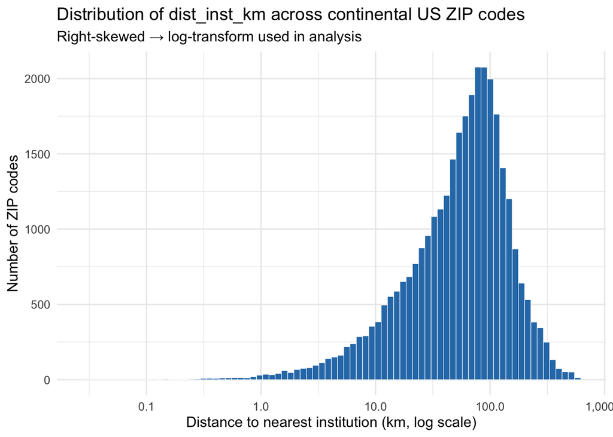

```r
ggplot(zipcode_distances, aes(x = dist_inst_km)) +
  geom_histogram(bins = 80, fill = "#2c7bb6", color = "white", linewidth = 0.2) +
  scale_x_log10(labels = scales::comma) +
  labs(
    x        = "Distance to nearest institution (km, log scale)",
    y        = "Number of ZIP codes",
    title    = "Distribution of dist_inst_km across continental US ZIP codes",
    subtitle = "Right-skewed → log-transform used in analysis"
  ) +
  theme_minimal(base_size = 12)
```

```r
saveRDS(zipcode_distances, here("data", "institutions", "zipcode_distances.rds"))
cat("Saved zipcode_distances.rds:", nrow(zipcode_distances), "rows\n")
```

```
Saved zipcode_distances.rds: 32657 rows
```